# CBM 122020

Kartheek Raj

1/2/2020

## Problem : Find the features impacting target variable i.e GT_Turbine_decay_state_coefficient and the best model yields better root mean square error.

Setting working directory

```r
getwd()
```

```
## [1] "C:/Users/mkart/OneDrive/Documents/Projects/ProcessingBigData/CBM/CBM"
```

```r
setwd("C:/Users/mkart/OneDrive/Documents/Projects/ProcessingBigData/CBM/CBM")
```

Data pulling from local machine for analysis.

```r
data <-read.delim("data.txt", header = FALSE, sep = "", quote = "\"",
           dec = ".", fill = F,stringsAsFactors= T)
cbm<-data.frame(data)
```

Checking first 10 rows

```r
head(cbm,10)
```

|  | V1 | V2 | V3 | V4 | V5 | V6 | V7 | V8 | V9 | V10 | V11 | V12 | V13 | V14 | V15 | V16 | V17 | V18 |
| --- | --- | --- | --- | --- | --- | --- | --- | --- | --- | --- | --- | --- | --- | --- | --- | --- | --- | --- |
| 1 | 1.138 | 3 | 289.964 | 1349.489 | 6677.380 | 7.584 | 7.584 | 464.006 | 288 | 550.563 | 1.096 | 0.998 | 5.947 | 1.019 | 7.137 | 0.082 | 0.95 | 0.975 |
| 2 | 2.088 | 6 | 6960.180 | 1376.166 | 6828.469 | 28.204 | 28.204 | 635.401 | 288 | 581.658 | 1.331 | 0.998 | 7.282 | 1.019 | 10.655 | 0.287 | 0.95 | 0.975 |
| 3 | 3.144 | 9 | 8379.229 | 1386.757 | 7111.811 | 60.358 | 60.358 | 606.002 | 288 | 587.587 | 1.389 | 0.998 | 7.574 | 1.020 | 13.086 | 0.259 | 0.95 | 0.975 |
| 4 | 4.161 | 12 | 14724.395 | 1547.465 | 7792.630 | 113.774 | 113.774 | 661.471 | 288 | 613.851 | 1.658 | 0.998 | 9.007 | 1.022 | 18.109 | 0.358 | 0.95 | 0.975 |
| 5 | 5.140 | 15 | 21636.432 | 1924.313 | 8494.777 | 175.306 | 175.306 | 731.494 | 288 | 645.642 | 2.078 | 0.998 | 11.197 | 1.026 | 26.373 | 0.522 | 0.95 | 0.975 |
| 6 | 6.175 | 18 | 29792.731 | 2307.404 | 8828.360 | 246.278 | 246.278 | 800.434 | 288 | 676.397 | 2.501 | 0.998 | 13.356 | 1.030 | 35.760 | 0.708 | 0.95 | 0.975 |
| 7 | 7.148 | 21 | 38982.180 | 2678.086 | 9132.429 | 332.077 | 332.077 | 854.747 | 288 | 699.954 | 2.963 | 0.998 | 15.679 | 1.035 | 45.881 | 0.908 | 0.95 | 0.975 |
| 8 | 8.206 | 24 | 50996.808 | 3087.561 | 9318.562 | 437.989 | 437.989 | 952.122 | 288 | 741.770 | 3.576 | 0.998 | 18.632 | 1.040 | 62.440 | 1.236 | 0.95 | 0.975 |
| 9 | 9.300 | 27 | 72763.329 | 3560.395 | 9778.528 | 644.905 | 644.905 | 1115.797 | 288 | 789.094 | 4.498 | 0.998 | 22.811 | 1.049 | 92.556 | 1.832 | 0.95 | 0.975 |
| 10 | 1.138 | 3 | 379.880 | 1355.375 | 6683.916 | 7.915 | 7.915 | 464.017 | 288 | 550.985 | 1.100 | 0.998 | 5.963 | 1.019 | 3.879 | 0.079 | 0.95 | 0.976 |

coloumn names not defined as required, assing coloumn names as inteded.

```r
colnames(cbm)<-c("Lever position (lp)",
                "Ship speed (v) [knots]",
                "Gas Turbine (GT) shaft torque (GTT) [kN m]",
                "GT rate of revolutions (GTn) [rpm]",
                "Gas Generator rate of revolutions (GGn) [rpm]",
                "Starboard Propeller Torque (Ts) [kN]",
                "Port Propeller Torque (Tp) [kN]",
                "Hight Pressure (HP) Turbine exit temperature (T48) [C]",
                "GT Compressor inlet air temperature (T1) [C]",
                "GT Compressor outlet air temperature (T2) [C]",
                "HP Turbine exit pressure (P48) [bar]",
                "GT Compressor inlet air pressure (P1) [bar]",
                "GT Compressor outlet air pressure (P2) [bar]",
                "GT exhaust gas pressure (Pexh) [bar]",
                "Turbine Injecton Control (TIC) [%]",
                "Fuel flow (mf) [kg/s]",
                 "GT Compressor decay state coefficient",
                 "GT_Turbine_decay_state_coefficient")
```

checking last 10 rows

```r
tail(cbm,10)
```

|  | Lever position (lp) | Ship speed (v) [knots] | Gas Turbine (GT) shaft torque (GTT) [kN m] | GT rate of revolutions (GTn) [rpm] | Gas Generator rate of revolutions (GGn) [rpm] | Starboard Propeller Torque (Ts) [kN] | Port Propeller Torque (Tp) [kN] | Hight Pressure (HP) Turbine exit temperature (T48) [C] | GT Compressor inlet air temperature (T1) [C] | GT Compressor outlet air temperature (T2) [C] | HP Turbine exit pressure (P48) [bar] | GT Compressor inlet air pressure (P1) [bar] | GT Compressor outlet air pressure (P2) [bar] | GT exhaust gas pressure (Pexh) [bar] | Turbine Injecton Control (TIC) [%] | Fuel flow (mf) [kg/s] | GT Compressor decay state coefficient | GT_Turbine_decay_state_coefficient |
| --- | --- | --- | --- | --- | --- | --- | --- | --- | --- | --- | --- | --- | --- | --- | --- | --- | --- | --- |
| 11925 | 9.300 | 27 | 72773.934 | 3560.398 | 9742.081 | 644.843 | 644.843 | 1039.245 | 288 | 767.743 | 4.532 | 0.998 | 22.491 | 1.052 | 86.168 | 1.706 | 1 | 0.999 |
| 11926 | 1.138 | 3 | 3131.810 | 1406.601 | 6673.118 | 10.692 | 10.692 | 510.408 | 288 | 552.868 | 1.213 | 0.998 | 6.451 | 1.019 | 0.088 | 0.146 | 1 | 1.000 |
| 11927 | 2.088 | 6 | 3881.963 | 1345.441 | 6761.168 | 22.478 | 22.478 | 519.295 | 288 | 555.401 | 1.231 | 0.998 | 6.566 | 1.020 | 20.720 | 0.172 | 1 | 1.000 |
| 11928 | 3.144 | 9 | 8375.659 | 1386.737 | 7063.239 | 60.319 | 60.319 | 563.854 | 288 | 573.260 | 1.391 | 0.998 | 7.416 | 1.021 | 11.419 | 0.226 | 1 | 1.000 |
| 11929 | 4.161 | 12 | 14718.321 | 1547.453 | 7729.639 | 113.743 | 113.743 | 617.242 | 288 | 599.109 | 1.663 | 0.998 | 8.830 | 1.023 | 16.151 | 0.320 | 1 | 1.000 |
| 11930 | 5.140 | 15 | 21624.934 | 1924.342 | 8470.013 | 175.239 | 175.239 | 681.658 | 288 | 628.950 | 2.087 | 0.998 | 10.990 | 1.027 | 23.803 | 0.471 | 1 | 1.000 |
| 11931 | 6.175 | 18 | 29763.213 | 2306.745 | 8800.352 | 245.954 | 245.954 | 747.405 | 288 | 658.853 | 2.512 | 0.998 | 13.109 | 1.031 | 32.671 | 0.647 | 1 | 1.000 |
| 11932 | 7.148 | 21 | 39003.867 | 2678.052 | 9120.889 | 332.389 | 332.389 | 796.457 | 288 | 680.393 | 2.982 | 0.998 | 15.420 | 1.036 | 42.104 | 0.834 | 1 | 1.000 |
| 11933 | 8.206 | 24 | 50992.579 | 3087.434 | 9300.274 | 438.024 | 438.024 | 892.945 | 288 | 722.029 | 3.594 | 0.998 | 18.293 | 1.043 | 58.064 | 1.149 | 1 | 1.000 |
| 11934 | 9.300 | 27 | 72775.130 | 3560.400 | 9742.950 | 644.880 | 644.880 | 1038.411 | 288 | 767.595 | 4.531 | 0.998 | 22.464 | 1.052 | 86.067 | 1.704 | 1 | 1.000 |

checking the data types in cbm data.we found all features numeric data type.

```r
str(cbm)
```

```
## 'data.frame':    11934 obs. of  18 variables:
##  $ Lever position (lp)                                   : num  1.14 2.09 3.14 4.16 5.14 ...
##  $ Ship speed (v) [knots]                                : num  3 6 9 12 15 18 21 24 27 3 ...
##  $ Gas Turbine (GT) shaft torque (GTT) [kN m]            : num  290 6960 8379 14724 21636 ...
##  $ GT rate of revolutions (GTn) [rpm]                    : num  1349 1376 1387 1547 1924 ...
##  $ Gas Generator rate of revolutions (GGn) [rpm]         : num  6677 6828 7112 7793 8495 ...
##  $ Starboard Propeller Torque (Ts) [kN]                  : num  7.58 28.2 60.36 113.77 175.31 ...
##  $ Port Propeller Torque (Tp) [kN]                       : num  7.58 28.2 60.36 113.77 175.31 ...
##  $ Hight Pressure (HP) Turbine exit temperature (T48) [C]: num  464 635 606 661 731 ...
##  $ GT Compressor inlet air temperature (T1) [C]          : num  288 288 288 288 288 288 288 288 288 288 ...
##  $ GT Compressor outlet air temperature (T2) [C]         : num  551 582 588 614 646 ...
##  $ HP Turbine exit pressure (P48) [bar]                  : num  1.1 1.33 1.39 1.66 2.08 ...
##  $ GT Compressor inlet air pressure (P1) [bar]           : num  0.998 0.998 0.998 0.998 0.998 0.998 0.998 0.998 0.998 0.998 ...
##  $ GT Compressor outlet air pressure (P2) [bar]          : num  5.95 7.28 7.57 9.01 11.2 ...
##  $ GT exhaust gas pressure (Pexh) [bar]                  : num  1.02 1.02 1.02 1.02 1.03 ...
##  $ Turbine Injecton Control (TIC) [%]                    : num  7.14 10.65 13.09 18.11 26.37 ...
##  $ Fuel flow (mf) [kg/s]                                 : num  0.082 0.287 0.259 0.358 0.522 ...
##  $ GT Compressor decay state coefficient                 : num  0.95 0.95 0.95 0.95 0.95 0.95 0.95 0.95 0.95 0.95 ...
##  $ GT_Turbine_decay_state_coefficient                    : num  0.975 0.975 0.975 0.975 0.975 0.975 0.975 0.975 0.975 0.976 ...
```

checking the quantity of features and variables in cbm data.

```r
dim(cbm)
```

```
## [1] 11934    18
```

numerical summary of the cbm dataset loike mean,median and mode.

```r
summary(cbm)
```

```
##  Lever position (lp) Ship speed (v) [knots]
##  Min.   :1.138       Min.   : 3
##  1st Qu.:3.144       1st Qu.: 9
##  Median :5.140       Median :15
##  Mean   :5.167       Mean   :15
##  3rd Qu.:7.148       3rd Qu.:21
##  Max.   :9.300       Max.   :27
##  Gas Turbine (GT) shaft torque (GTT) [kN m] GT rate of revolutions (GTn) [rpm]
##  Min.   :  253.6                            Min.   :1308
##  1st Qu.: 8375.9                            1st Qu.:1387
##  Median :21630.7                            Median :1924
##  Mean   :27247.5                            Mean   :2136
##  3rd Qu.:39001.4                            3rd Qu.:2678
##  Max.   :72784.9                            Max.   :3561
##  Gas Generator rate of revolutions (GGn) [rpm]
##  Min.   :6589
##  1st Qu.:7058
##  Median :8482
##  Mean   :8201
##  3rd Qu.:9133
##  Max.   :9797
##  Starboard Propeller Torque (Ts) [kN] Port Propeller Torque (Tp) [kN]
##  Min.   :  5.304                      Min.   :  5.304
##  1st Qu.: 60.317                      1st Qu.: 60.317
##  Median :175.268                      Median :175.268
##  Mean   :227.336                      Mean   :227.336
##  3rd Qu.:332.365                      3rd Qu.:332.365
##  Max.   :645.249                      Max.   :645.249
##  Hight Pressure (HP) Turbine exit temperature (T48) [C]
##  Min.   : 442.4
##  1st Qu.: 589.9
##  Median : 706.0
##  Mean   : 735.5
##  3rd Qu.: 834.1
##  Max.   :1115.8
##  GT Compressor inlet air temperature (T1) [C]
##  Min.   :288
##  1st Qu.:288
##  Median :288
##  Mean   :288
```

[output cut: 36 more lines]

```
##  Max.   :1.052                        Max.   :92.56
##  Fuel flow (mf) [kg/s] GT Compressor decay state coefficient
##  Min.   :0.0680        Min.   :0.950
##  1st Qu.:0.2460        1st Qu.:0.962
##  Median :0.4960        Median :0.975
##  Mean   :0.6624        Mean   :0.975
##  3rd Qu.:0.8820        3rd Qu.:0.988
##  Max.   :1.8320        Max.   :1.000
##  GT_Turbine_decay_state_coefficient
##  Min.   :0.9750
##  1st Qu.:0.9810
##  Median :0.9875
##  Mean   :0.9875
##  3rd Qu.:0.9940
##  Max.   :1.0000
```

Checking for missing values.Found no missing values in the data.

```r
sum(is.na(cbm))
```

```
## [1] 0
```

Checking for null values.Found no missing values in the data.

```r
sum(is.null(cbm))
```

```
## [1] 0
```

checking **correlation** between feautures.

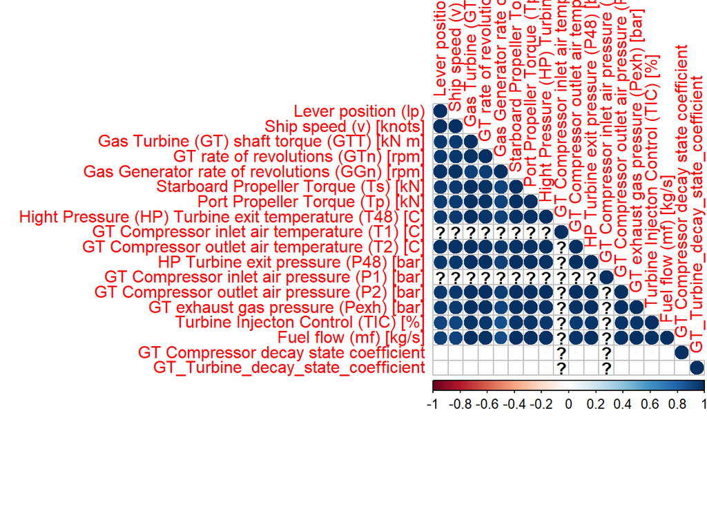

```r
par(mfrow=c(1,1),bg="lightyellow")
library(corrplot)
cbmcorplot<-cor(cbm)
corrplot(cbmcorplot,method = "circle",type="lower")
```

```r
var(cbm$`GT Compressor inlet air temperature (T1) [C]`)
```

```
## [1] 0
```

```r
var(cbm$`GT Compressor inlet air pressure (P1) [bar]`)
```

```
## [1] 0
```

```r
sum(cbm$`Starboard Propeller Torque (Ts) [kN]`-cbm$`Port Propeller Torque (Tp) [kN]`)
```

```
## [1] 0
```

**Insight 2** : As variance is zero we will remove those features from the dataset.

## Exploiry data analysis

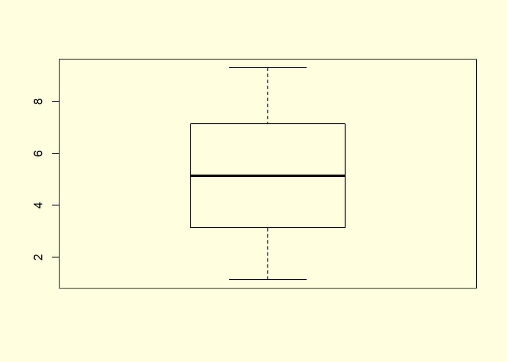

```r
par(mfrow=c(1,1),bg="lightyellow")
boxplot(cbm$`Lever position (lp)`)
```

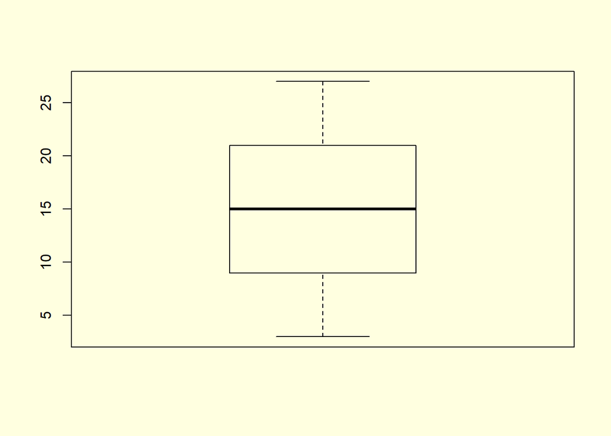

```r
boxplot(cbm$`Ship speed (v) [knots]`)
```

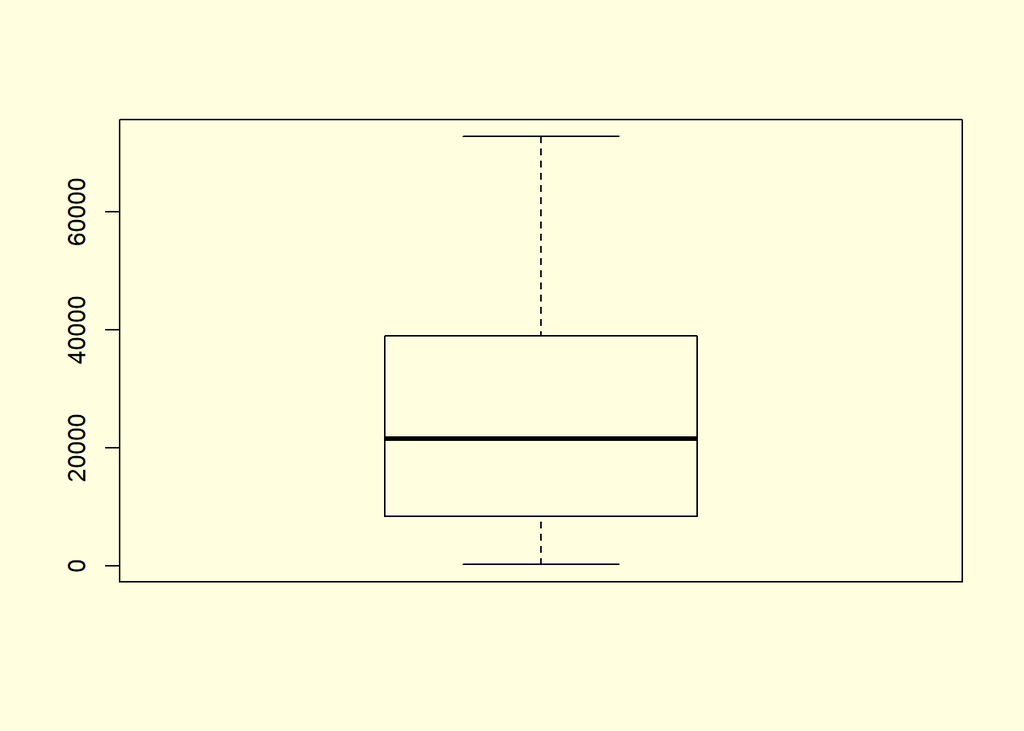

```r
boxplot(cbm$`Gas Turbine (GT) shaft torque (GTT) [kN m]`)
```

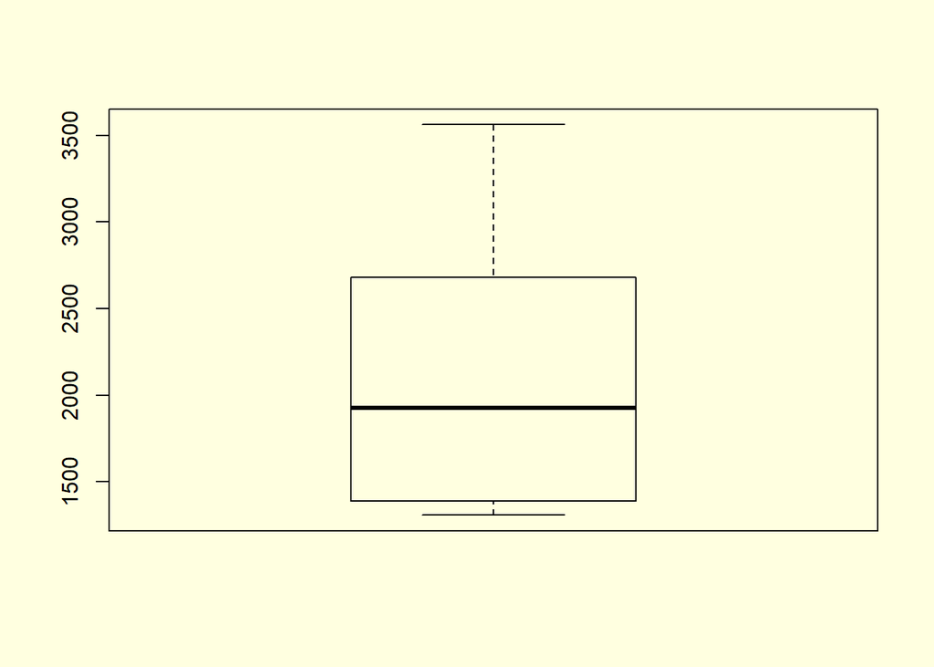

```r
boxplot(cbm$`GT rate of revolutions (GTn) [rpm]`)
```

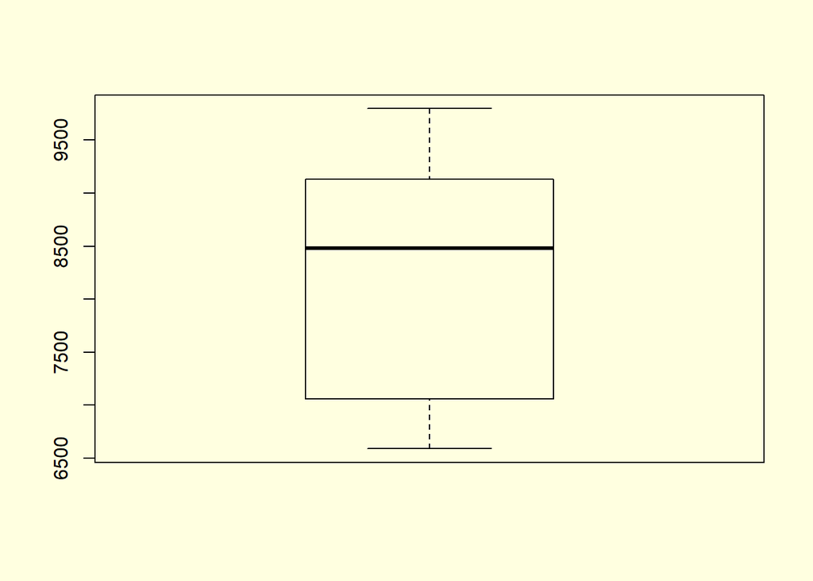

```r
boxplot(cbm$`Gas Generator rate of revolutions (GGn) [rpm]`)
```

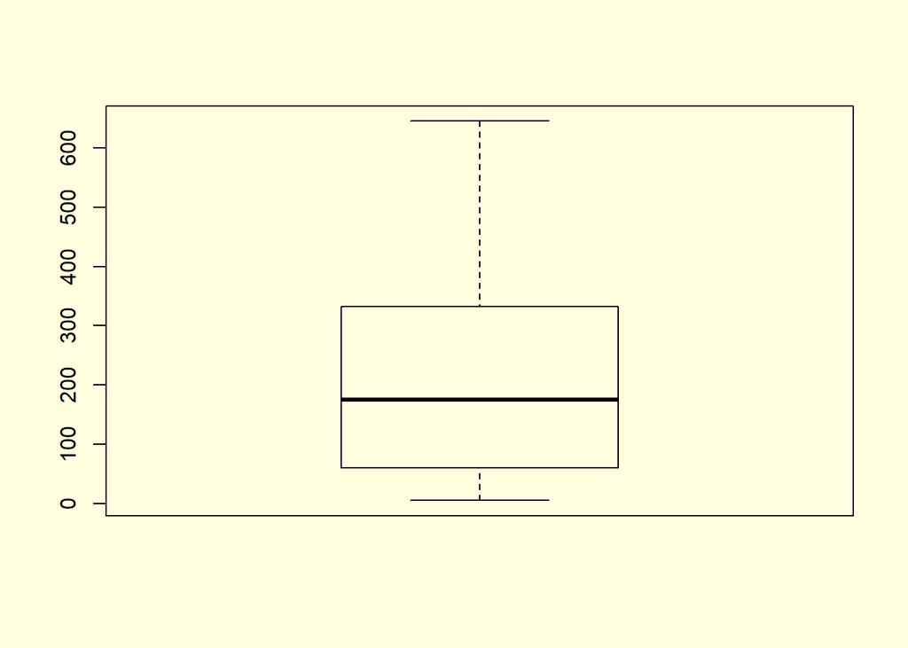

```r
boxplot(cbm$`Starboard Propeller Torque (Ts) [kN]`)
boxplot(cbm$`Port Propeller Torque (Tp) [kN]`)
```

[output not shown]

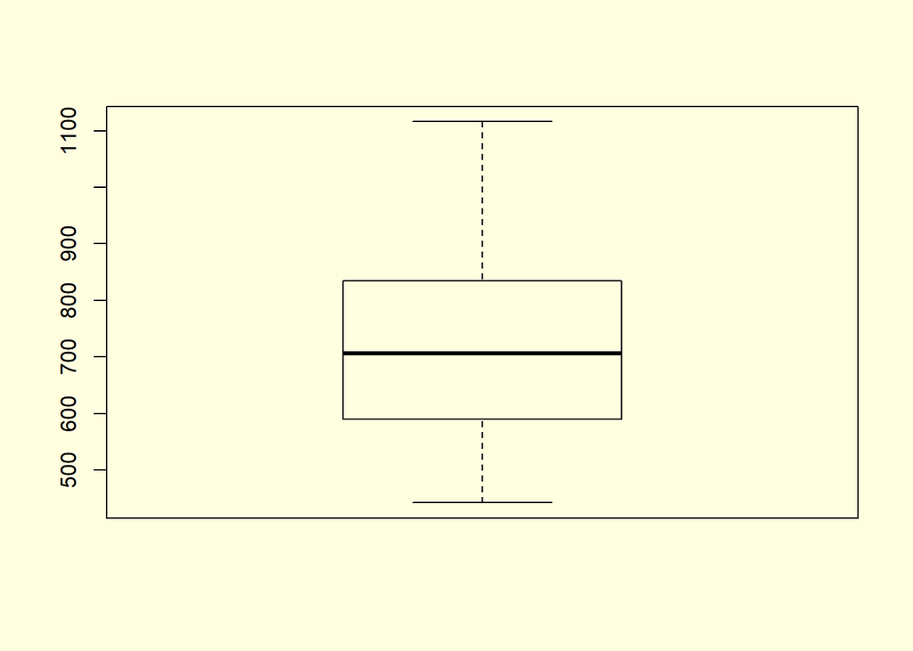

```r
boxplot(cbm$`Hight Pressure (HP) Turbine exit temperature (T48) [C]`)
```

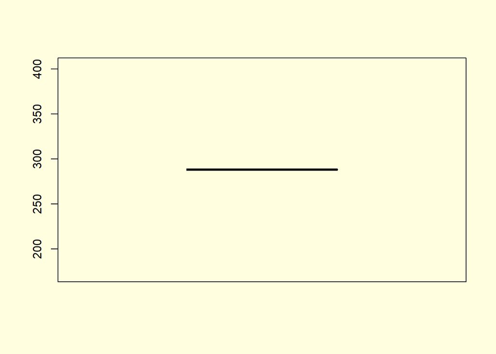

```r
boxplot(cbm$`GT Compressor inlet air temperature (T1) [C]`)
```

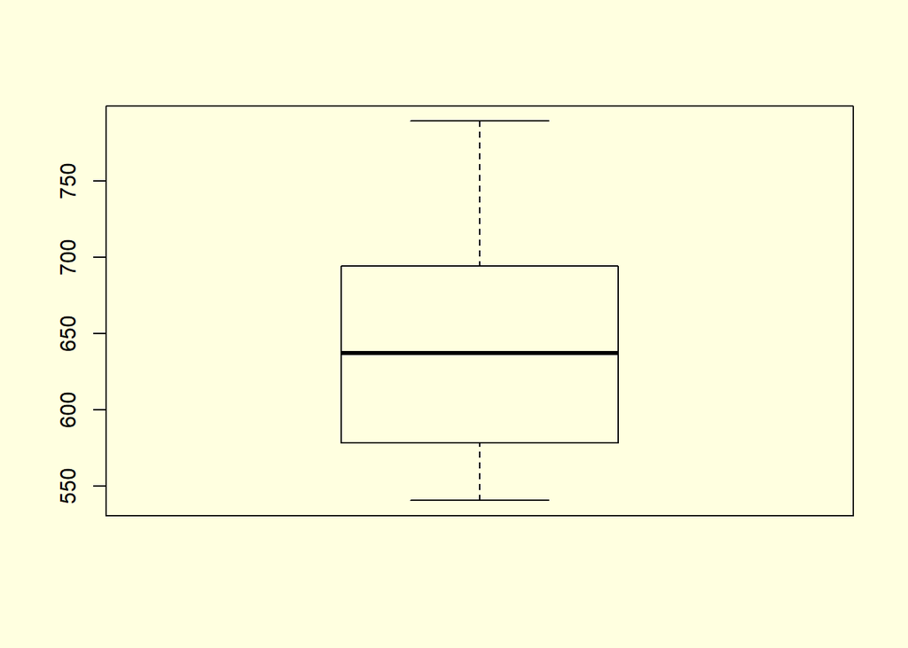

```r
boxplot(cbm$`GT Compressor outlet air temperature (T2) [C]`)
```

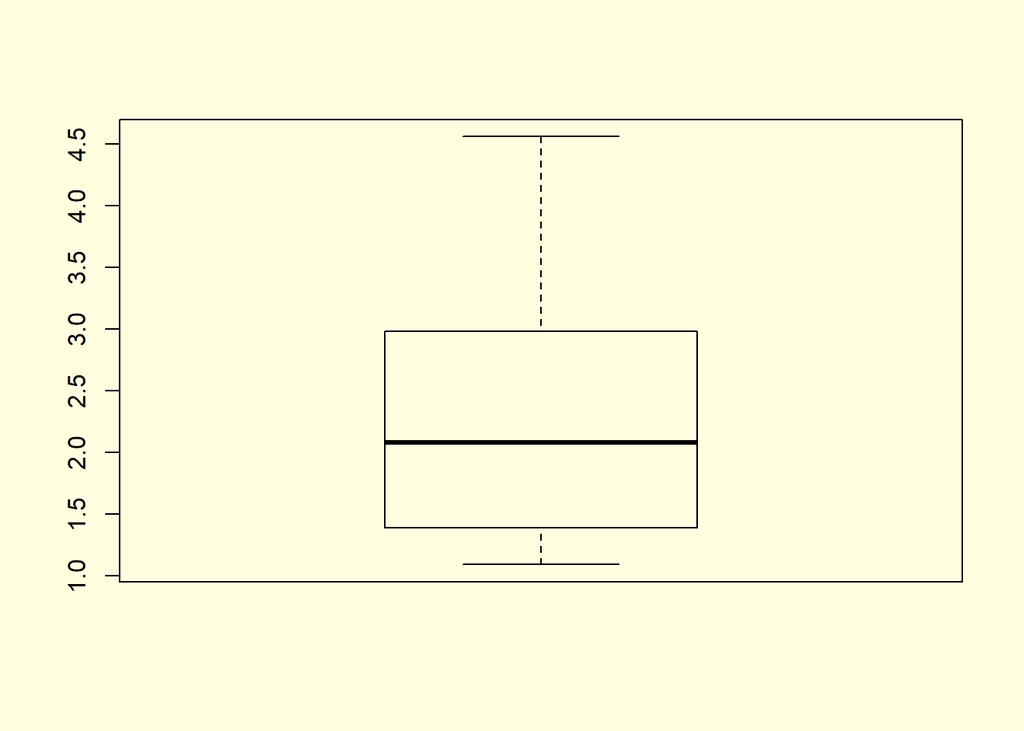

```r
boxplot(cbm$`HP Turbine exit pressure (P48) [bar]`)
```

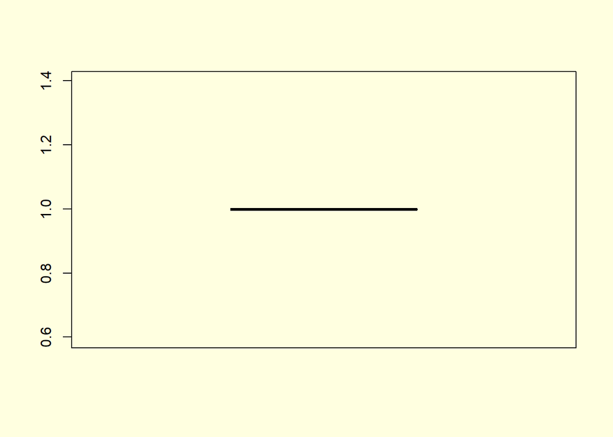

```r
boxplot(cbm$`GT Compressor inlet air pressure (P1) [bar]`)
```

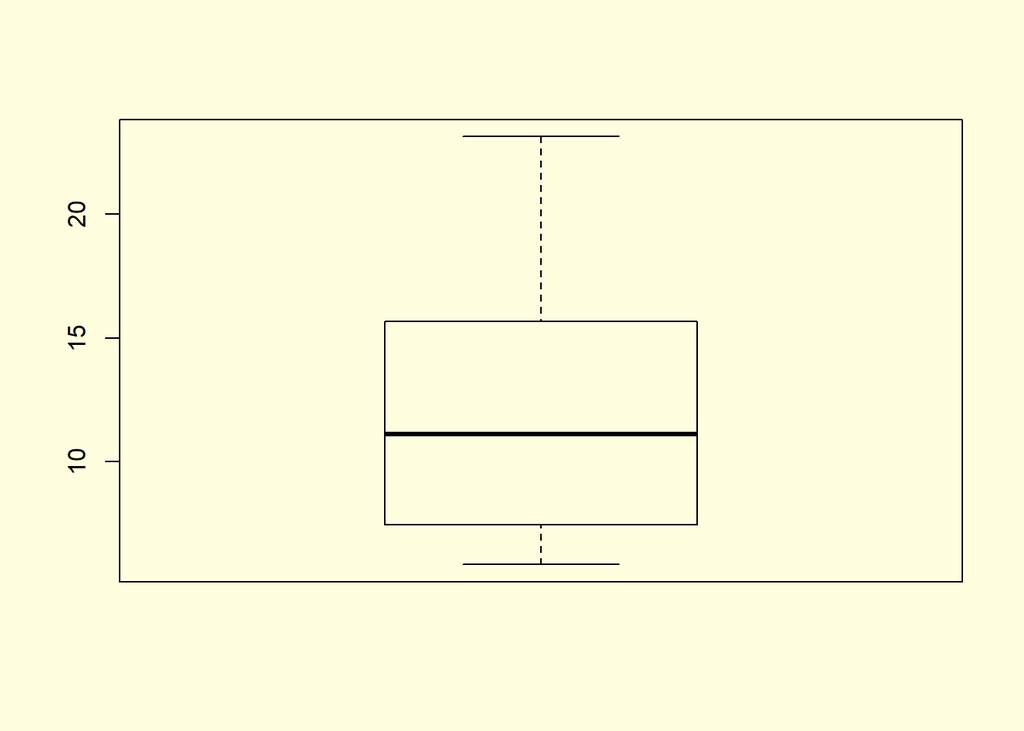

```r
boxplot(cbm$`GT Compressor outlet air pressure (P2) [bar]`)
```

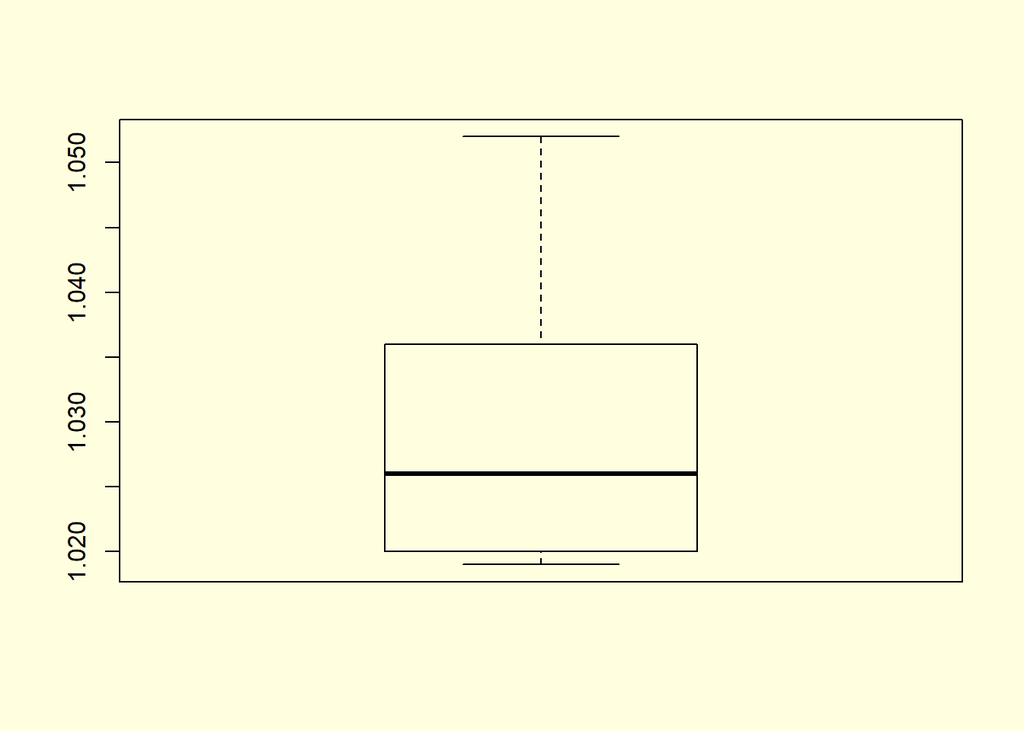

```r
boxplot(cbm$`GT exhaust gas pressure (Pexh) [bar]`)
```

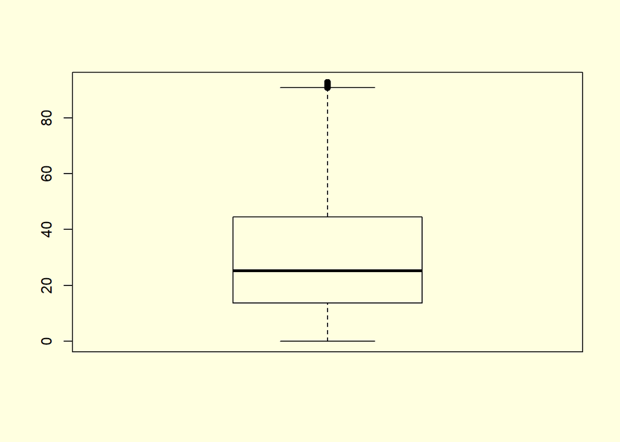

```r
boxplot(cbm$`Turbine Injecton Control (TIC) [%]`)
```

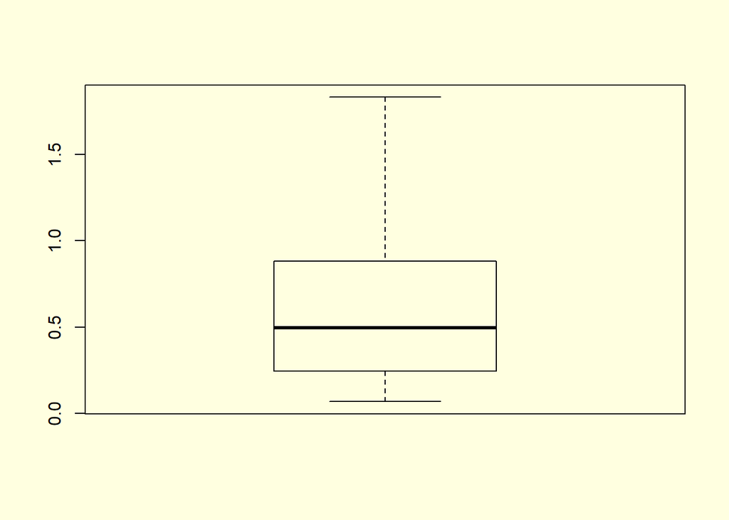

```r
boxplot(cbm$`Fuel flow (mf) [kg/s]`)
```

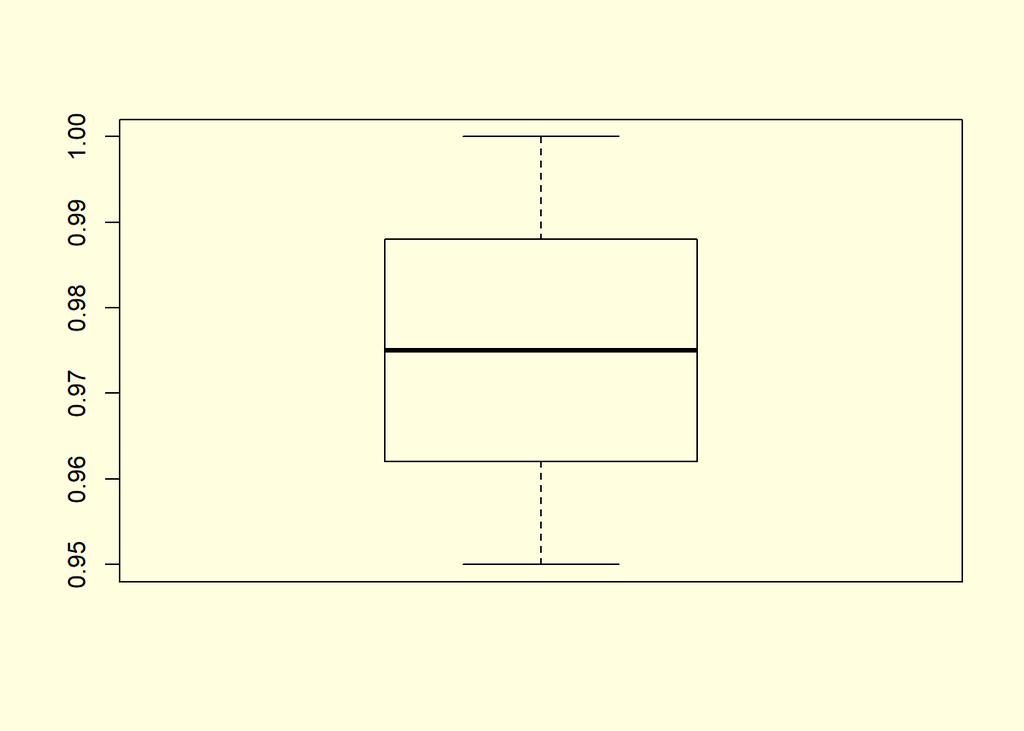

```r
boxplot(cbm$`GT Compressor decay state coefficient`)
```

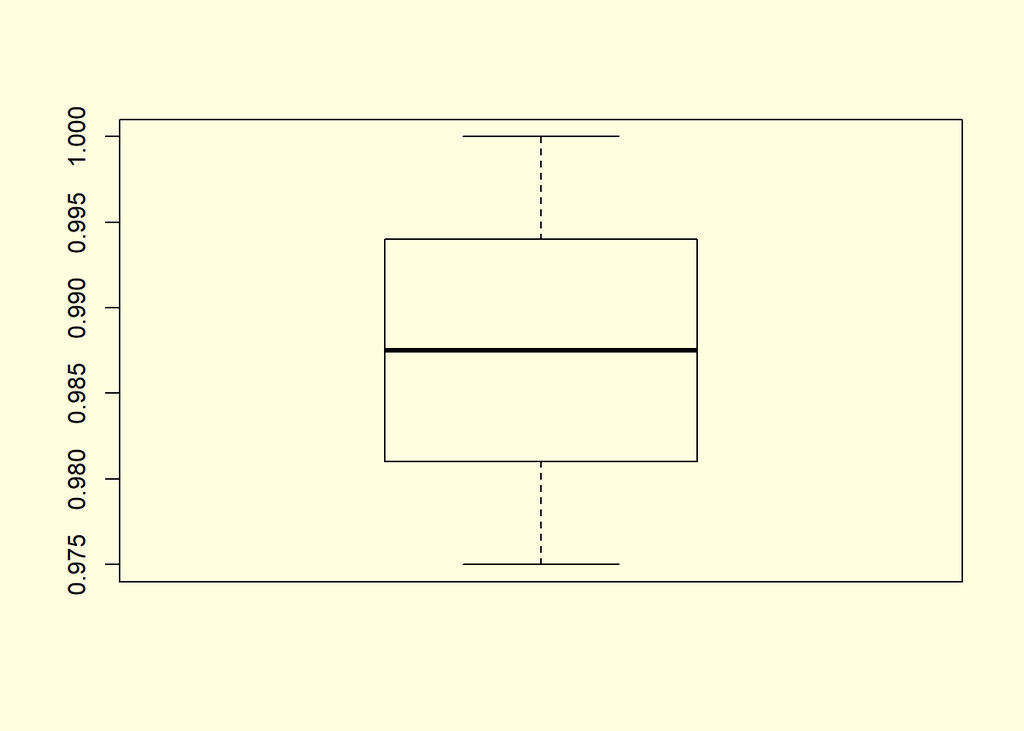

```r
boxplot(cbm$`GT_Turbine_decay_state_coefficient`)
```

**Insight 3**: Tutbine injection control (TIC) is the feature has 188 outliers out of 11934 records is small.Even very small quantity still we handle outliers replacing by by upper whisker.

Handling outliers in the TIC feauture

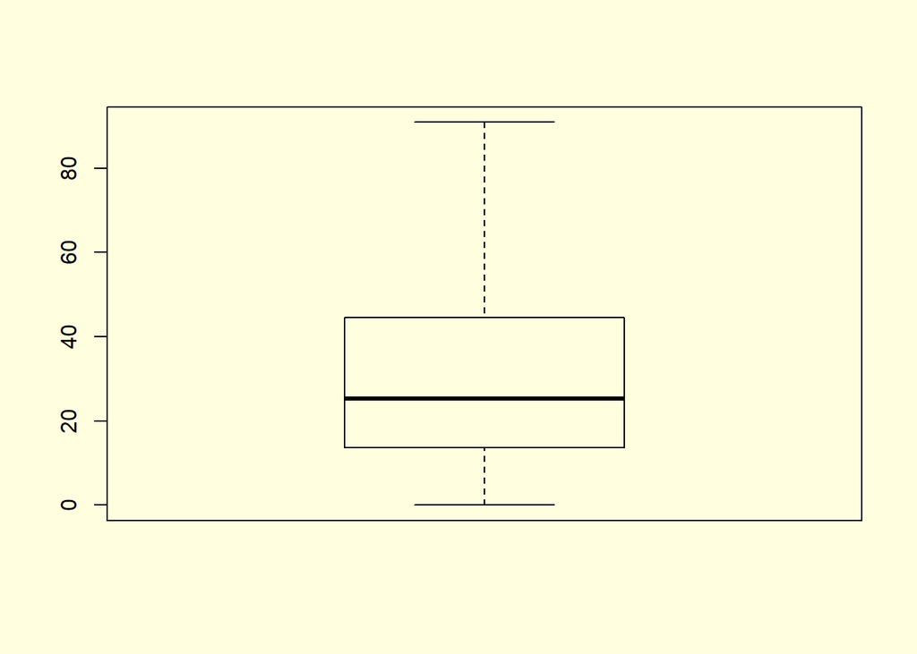

```r
par(mfrow=c(1,1),bg="lightyellow")
#Function for replace outliers
replace_outliers = function(x,na.rm= TRUE){

qnt = quantile(x, probs = c(.25,.75))
outlier = 1.5*IQR(x)
x[x < (qnt[1]-outlier) ] <- qnt[1]
x[x > (qnt[2]+outlier) ] <- qnt[2]
return(x)
}
cbm$`Turbine Injecton Control (TIC) [%]`<-replace_outliers(cbm$`Turbine Injecton Control (TIC) [%]`)
boxplot(cbm$`Turbine Injecton Control (TIC) [%]`)
```

plotting **histogram** feautures.

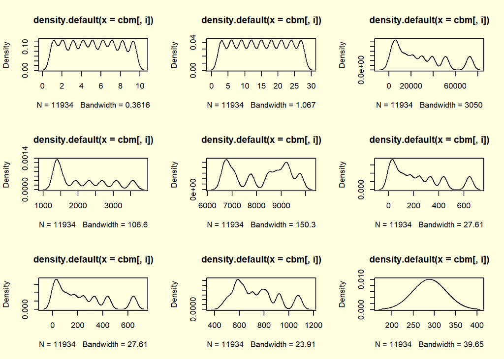

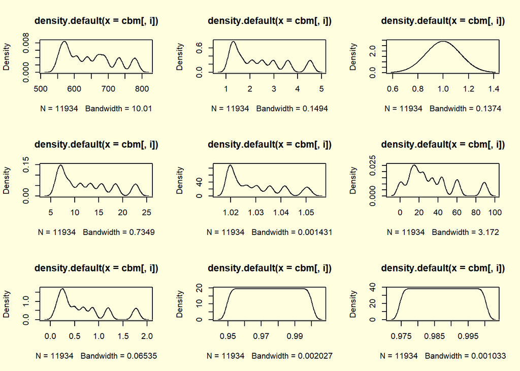

```r
par(mfrow=c(3,3),bg="lightyellow")
for (i in 1:ncol(cbm)) {
  d<-density(cbm[,i])
  plot(d)

}
```

Removing the features as found insight 2

```r
cbmu<-cbm[,-c(7,9,12,17)]
colnames(cbmu)
```

```
##  [1] "Lever position (lp)"
##  [2] "Ship speed (v) [knots]"
##  [3] "Gas Turbine (GT) shaft torque (GTT) [kN m]"
##  [4] "GT rate of revolutions (GTn) [rpm]"
##  [5] "Gas Generator rate of revolutions (GGn) [rpm]"
##  [6] "Starboard Propeller Torque (Ts) [kN]"
##  [7] "Hight Pressure (HP) Turbine exit temperature (T48) [C]"
##  [8] "GT Compressor outlet air temperature (T2) [C]"
##  [9] "HP Turbine exit pressure (P48) [bar]"
## [10] "GT Compressor outlet air pressure (P2) [bar]"
## [11] "GT exhaust gas pressure (Pexh) [bar]"
## [12] "Turbine Injecton Control (TIC) [%]"
## [13] "Fuel flow (mf) [kg/s]"
## [14] "GT_Turbine_decay_state_coefficient"
```

performing **train and test data split**.

```r
set.seed(1234)
ids = sample(nrow(cbmu), nrow(cbmu)*0.6)
train<-data.frame(cbmu[ids,])
test<-data.frame(cbmu[-ids,])
```

**z score Scaling** the data.

```r
train_withou_Y<-train[,-c(14)]
test_withou_Y<-test[,-c(14)]

train_zscale<-data.frame(scale(train_withou_Y))
test_zscale<-data.frame(scale(test_withou_Y))
head(train_zscale)
```

|  | Lever.position..lp. | Ship.speed..v...knots. | Gas.Turbine..GT..shaft.torque..GTT...kN.m. | GT.rate.of.revolutions..GTn...rpm. | Gas.Generator.rate.of.revolutions..GGn...rpm. | Starboard.Propeller.Torque..Ts...kN. | Hight.Pressure..HP..Turbine.exit.temperature..T48...C. | GT.Compressor.outlet.air.temperature..T2...C. | HP.Turbine.exit.pressure..P48...bar. | GT.Compressor.outlet.air.pressure..P2...bar. | GT.exhaust.gas.pressure..Pexh...bar. | Turbine.Injecton.Control..TIC..... | Fuel.flow..mf...kg.s. |
| --- | --- | --- | --- | --- | --- | --- | --- | --- | --- | --- | --- | --- | --- |
| 7452 | 1.5819556 | 1.5574706 | 2.0602075 | 1.8483556 | 1.4359502 | 2.0860876 | 1.8846280 | 1.7760527 | 1.9957672 | 1.9084597 | 2.07936173 | 2.22139947 | 2.12749875 |
| 8016 | 0.3935042 | 0.3970256 | 0.1212794 | 0.2298238 | 0.5555773 | 0.1005187 | 0.2386647 | 0.2906860 | 0.1550815 | 0.2027858 | 0.05970584 | 0.06692786 | 0.04529687 |
| 7162 | 0.7635404 | 0.7838406 | 0.5374577 | 0.7091705 | 0.8554823 | 0.5300546 | 0.4877293 | 0.5832129 | 0.5814134 | 0.6124994 | 0.63675038 | 0.43596782 | 0.40151477 |
| 8086 | -0.3724290 | -0.3766044 | -0.5567321 | -0.7505758 | -0.4083156 | -0.5574466 | -0.5791260 | -0.5689311 | -0.6276012 | -0.6245025 | -0.61351279 | -0.63929452 | -0.63958617 |
| 7269 | 0.3935042 | 0.3970256 | 0.1212597 | 0.2298625 | 0.5537797 | 0.1005088 | 0.2795192 | 0.3159750 | 0.1550815 | 0.2145775 | 0.05970584 | 0.08472942 | 0.06104131 |
| 9196 | 0.7635404 | 0.7838406 | 0.5379594 | 0.7091098 | 0.8479048 | 0.5306122 | 0.5007668 | 0.5646585 | 0.5915423 | 0.6433823 | 0.63675038 | 0.44933912 | 0.41529115 |

```r
head(test_zscale)
```

|  | Lever.position..lp. | Ship.speed..v...knots. | Gas.Turbine..GT..shaft.torque..GTT...kN.m. | GT.rate.of.revolutions..GTn...rpm. | Gas.Generator.rate.of.revolutions..GGn...rpm. | Starboard.Propeller.Torque..Ts...kN. | Hight.Pressure..HP..Turbine.exit.temperature..T48...C. | GT.Compressor.outlet.air.temperature..T2...C. | HP.Turbine.exit.pressure..P48...bar. | GT.Compressor.outlet.air.pressure..P2...bar. | GT.exhaust.gas.pressure..Pexh...bar. | Turbine.Injecton.Control..TIC..... | Fuel.flow..mf...kg.s. |
| --- | --- | --- | --- | --- | --- | --- | --- | --- | --- | --- | --- | --- | --- |
| 2 | -1.1894658 | -1.1794258 | -0.9302193 | -0.9974135 | -1.2772653 | -1.00813539 | -0.5884885 | -0.9030554 | -0.9567478 | -0.9544418 | -1.02288442 | -0.9047142 | -0.7527232 |
| 3 | -0.7866480 | -0.7914044 | -0.8659906 | -0.9837187 | -1.0167766 | -0.84728111 | -0.7581664 | -0.8213302 | -0.9031865 | -0.8996498 | -0.92653174 | -0.8065829 | -0.8080963 |
| 4 | -0.3987070 | -0.4033830 | -0.5787971 | -0.7759140 | -0.3908699 | -0.58006109 | -0.4380241 | -0.4593074 | -0.6547728 | -0.6307560 | -0.73382637 | -0.6038213 | -0.6123128 |
| 6 | 0.3695458 | 0.3726599 | 0.1032227 | 0.2067310 | 0.5613221 | 0.08280625 | 0.3640081 | 0.4028263 | 0.1237130 | 0.1853077 | 0.03699507 | 0.1086903 | 0.0798509 |
| 7 | 0.7407028 | 0.7606813 | 0.5191536 | 0.6860442 | 0.8408660 | 0.51202615 | 0.6774784 | 0.7275358 | 0.5503564 | 0.6212046 | 0.51875847 | 0.5172410 | 0.4753730 |
| 8 | 1.1442835 | 1.1487027 | 1.0629571 | 1.2155190 | 1.0119862 | 1.04186378 | 1.2394833 | 1.3039272 | 1.1164440 | 1.1753173 | 1.00052187 | 1.1856722 | 1.1240294 |

performing **minmax scaling** on the dataset

```r
minmax<-function(x){
  return((x-min(x))/max(x)-min(x))
}

train_minmax<-data.frame(minmax(train_withou_Y))
test_minmax<-data.frame(minmax(test_withou_Y))
```

## Linear regression

Fitting linear regression models to both train data sets

```r
Y_train<-train$GT_Turbine_decay_state_coefficient
Y_test<-test$GT_Turbine_decay_state_coefficient

train_zscale_withY<-cbind(train_zscale[,],Y_train)
train_minmax_withY<-cbind(train_minmax[,],Y_train)

test_zscale_withY<-cbind(test_zscale[,],Y_test)
test_minmax_withY<-cbind(test_minmax[,],Y_test)


lmode_z<-lm (Y_train~.,data=train_zscale_withY)
lmode_minmax<-lm (Y_train~.,data=train_minmax_withY)
summary(lmode_z)
```

```
##
## Call:
## lm(formula = Y_train ~ ., data = train_zscale_withY)
##
## Residuals:
##       Min        1Q    Median        3Q       Max
## -0.009473 -0.001369  0.000018  0.001410  0.007945
##
## Coefficients:
##                                                          Estimate Std. Error
## (Intercept)                                             9.875e-01  2.708e-05
## Lever.position..lp.                                    -1.996e-02  5.411e-03
## Ship.speed..v...knots.                                  5.953e-02  5.041e-03
## Gas.Turbine..GT..shaft.torque..GTT...kN.m.              2.925e-01  3.723e-03
## GT.rate.of.revolutions..GTn...rpm.                      4.223e-02  1.060e-03
## Gas.Generator.rate.of.revolutions..GGn...rpm.           2.868e-02  3.700e-04
## Starboard.Propeller.Torque..Ts...kN.                   -2.914e-01  2.730e-03
## Hight.Pressure..HP..Turbine.exit.temperature..T48...C. -1.049e-01  1.508e-03
## GT.Compressor.outlet.air.temperature..T2...C.           1.768e-02  1.057e-03
## HP.Turbine.exit.pressure..P48...bar.                    1.274e-01  4.739e-03
## GT.Compressor.outlet.air.pressure..P2...bar.           -2.941e-01  2.137e-03
## GT.exhaust.gas.pressure..Pexh...bar.                    8.577e-03  9.601e-04
## Turbine.Injecton.Control..TIC.....                     -2.092e-03  1.039e-04
## Fuel.flow..mf...kg.s.                                   1.390e-01  2.185e-03
##                                                          t value Pr(>|t|)
## (Intercept)                                            36460.551  < 2e-16 ***
## Lever.position..lp.                                       -3.689 0.000227 ***
## Ship.speed..v...knots.                                    11.810  < 2e-16 ***
## Gas.Turbine..GT..shaft.torque..GTT...kN.m.                78.561  < 2e-16 ***
## GT.rate.of.revolutions..GTn...rpm.                        39.817  < 2e-16 ***
## Gas.Generator.rate.of.revolutions..GGn...rpm.             77.534  < 2e-16 ***
## Starboard.Propeller.Torque..Ts...kN.                    -106.747  < 2e-16 ***
## Hight.Pressure..HP..Turbine.exit.temperature..T48...C.   -69.539  < 2e-16 ***
## GT.Compressor.outlet.air.temperature..T2...C.             16.727  < 2e-16 ***
## HP.Turbine.exit.pressure..P48...bar.                      26.875  < 2e-16 ***
## GT.Compressor.outlet.air.pressure..P2...bar.            -137.662  < 2e-16 ***
## GT.exhaust.gas.pressure..Pexh...bar.                       8.934  < 2e-16 ***
## Turbine.Injecton.Control..TIC.....                       -20.134  < 2e-16 ***
## Fuel.flow..mf...kg.s.                                     63.596  < 2e-16 ***
## ---
## Signif. codes:  0 '***' 0.001 '**' 0.01 '*' 0.05 '.' 0.1 ' ' 1
##
## Residual standard error: 0.002292 on 7146 degrees of freedom
## Multiple R-squared:  0.906,  Adjusted R-squared:  0.9058
## F-statistic:  5299 on 13 and 7146 DF,  p-value: < 2.2e-16
```

```r
summary(lmode_minmax)
```

```
##
## Call:
## lm(formula = Y_train ~ ., data = train_minmax_withY)
##
## Residuals:
##       Min        1Q    Median        3Q       Max
## -0.009473 -0.001369  0.000018  0.001410  0.007945
##
## Coefficients:
##                                                          Estimate Std. Error
## (Intercept)                                             2.102e-01  9.438e-02
## Lever.position..lp.                                    -5.525e+02  1.498e+02
## Ship.speed..v...knots.                                  5.587e+02  4.731e+01
## Gas.Turbine..GT..shaft.torque..GTT...kN.m.              9.596e-01  1.221e-02
## GT.rate.of.revolutions..GTn...rpm.                      3.968e+00  9.966e-02
## Gas.Generator.rate.of.revolutions..GGn...rpm.           1.909e+00  2.462e-02
## Starboard.Propeller.Torque..Ts...kN.                   -1.056e+02  9.889e-01
## Hight.Pressure..HP..Turbine.exit.temperature..T48...C. -4.388e+01  6.310e-01
## GT.Compressor.outlet.air.temperature..T2...C.           1.769e+01  1.057e+00
## HP.Turbine.exit.pressure..P48...bar.                    8.537e+03  3.176e+02
## GT.Compressor.outlet.air.pressure..P2...bar.           -4.007e+03  2.911e+01
## GT.exhaust.gas.pressure..Pexh...bar.                    6.004e+04  6.721e+03
## Turbine.Injecton.Control..TIC.....                     -6.131e+00  3.045e-01
## Fuel.flow..mf...kg.s.                                   1.991e+04  3.131e+02
##                                                         t value Pr(>|t|)
## (Intercept)                                               2.227 0.025945 *
## Lever.position..lp.                                      -3.689 0.000227 ***
## Ship.speed..v...knots.                                   11.810  < 2e-16 ***
## Gas.Turbine..GT..shaft.torque..GTT...kN.m.               78.561  < 2e-16 ***
## GT.rate.of.revolutions..GTn...rpm.                       39.817  < 2e-16 ***
## Gas.Generator.rate.of.revolutions..GGn...rpm.            77.534  < 2e-16 ***
## Starboard.Propeller.Torque..Ts...kN.                   -106.747  < 2e-16 ***
## Hight.Pressure..HP..Turbine.exit.temperature..T48...C.  -69.539  < 2e-16 ***
## GT.Compressor.outlet.air.temperature..T2...C.            16.727  < 2e-16 ***
## HP.Turbine.exit.pressure..P48...bar.                     26.875  < 2e-16 ***
## GT.Compressor.outlet.air.pressure..P2...bar.           -137.662  < 2e-16 ***
## GT.exhaust.gas.pressure..Pexh...bar.                      8.934  < 2e-16 ***
## Turbine.Injecton.Control..TIC.....                      -20.134  < 2e-16 ***
## Fuel.flow..mf...kg.s.                                    63.596  < 2e-16 ***
## ---
## Signif. codes:  0 '***' 0.001 '**' 0.01 '*' 0.05 '.' 0.1 ' ' 1
##
## Residual standard error: 0.002292 on 7146 degrees of freedom
## Multiple R-squared:  0.906,  Adjusted R-squared:  0.9058
## F-statistic:  5299 on 13 and 7146 DF,  p-value: < 2.2e-16
```

```r
lmode_z$coefficients
```

```
##                                            (Intercept)
##                                            0.987497486
##                                    Lever.position..lp.
##                                           -0.019961249
##                                 Ship.speed..v...knots.
##                                            0.059532973
##             Gas.Turbine..GT..shaft.torque..GTT...kN.m.
##                                            0.292488172
##                     GT.rate.of.revolutions..GTn...rpm.
##                                            0.042225463
##          Gas.Generator.rate.of.revolutions..GGn...rpm.
##                                            0.028683249
##                   Starboard.Propeller.Torque..Ts...kN.
##                                           -0.291373873
## Hight.Pressure..HP..Turbine.exit.temperature..T48...C.
##                                           -0.104872232
##          GT.Compressor.outlet.air.temperature..T2...C.
##                                            0.017681427
##                   HP.Turbine.exit.pressure..P48...bar.
##                                            0.127373243
##           GT.Compressor.outlet.air.pressure..P2...bar.
##                                           -0.294119771
##                   GT.exhaust.gas.pressure..Pexh...bar.
##                                            0.008577395
##                     Turbine.Injecton.Control..TIC.....
##                                           -0.002091655
##                                  Fuel.flow..mf...kg.s.
##                                            0.138984688
```

**predicting** on **test data** using previous models.

```r
lmode_z_predictions<-predict(lmode_z, newdata=test_zscale_withY)
lmode_minmax_predictions<-predict(lmode_minmax, newdata=test_minmax_withY)
```

**Root mean square error function**

```r
rmse<-function(x){

testerror<- (Y_test-x)
testerror_sq <- testerror ** 2
rmse<-sqrt(mean(testerror_sq))
rmse

}

rmse(lmode_z_predictions)
```

```
## [1] 0.002299194
```

```r
rmse(lmode_minmax_predictions)
```

```
## [1] 0.00230002
```

we can clearly evident r-square value is 0.90 but the **feature significance** post **close values**.To handel this we **perform ridge regeressoion as handels multicolinearity**.

## Ridge regression

```r
par(mfrow=c(1,1),bg="lightyellow")

require(glmnet)
library(glmnet)

x_reg<-data.matrix(train_withou_Y)
y_reg<-Y_train
lambda_seq <- 10^seq(2, -2, by = -.1)

ridge_model <- glmnet(x_reg, y_reg, alpha = 0, lambda  = lambda_seq,standardize = FALSE)
summary(ridge_model)
```

```
##           Length Class     Mode
## a0         41    -none-    numeric
## beta      533    dgCMatrix S4
## df         41    -none-    numeric
## dim         2    -none-    numeric
## lambda     41    -none-    numeric
## dev.ratio  41    -none-    numeric
## nulldev     1    -none-    numeric
## npasses     1    -none-    numeric
## jerr        1    -none-    numeric
## offset      1    -none-    logical
## call        6    -none-    call
## nobs        1    -none-    numeric
```

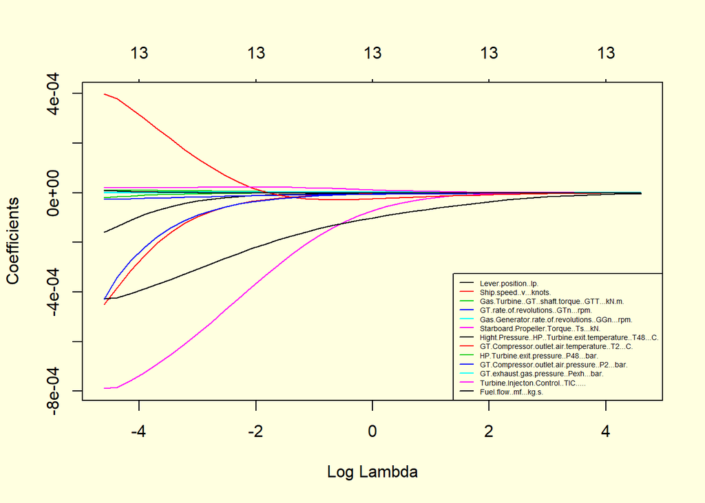

```r
plot(ridge_model, xvar = "lambda")
legend("bottomright", lwd = 1, col = 1:6, legend = colnames(x_reg), cex = .45)
```

Finding the **optimal lambda**

```r
par(mfrow=c(1,1),bg="lightyellow")

lambdas_to_try <- 10^seq(-3, 3, length.out = 50)
ridge_cv <- cv.glmnet(x_reg, y_reg, alpha = 0,lambda = lambdas_to_try ,nfolds = 100)
best_lambda<-ridge_cv$lambda.min
best_lambda
```

```
## [1] 0.001
```

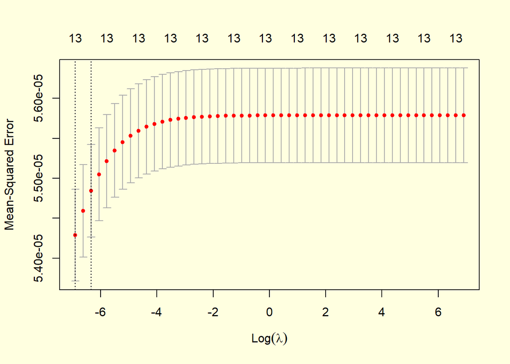

```r
plot(ridge_cv)
```

Final ridge regression model with optimal lambda value

```r
x_reg<-data.matrix(train_withou_Y)
y_reg<-Y_train
lambda_seq <- 10^seq(2, -2, by = -.1)

final_ridge_model <- glmnet(x_reg, y_reg, alpha = 0, lambda  = best_lambda ,standardize = FALSE)
coef(final_ridge_model)
```

```
## 14 x 1 sparse Matrix of class "dgCMatrix"
##                                                                   s0
## (Intercept)                                             9.070571e-01
## Lever.position..lp.                                    -5.175049e-04
## Ship.speed..v...knots.                                 -1.076006e-03
## Gas.Turbine..GT..shaft.torque..GTT...kN.m.              1.229369e-05
## GT.rate.of.revolutions..GTn...rpm.                     -2.593418e-05
## Gas.Generator.rate.of.revolutions..GGn...rpm.           3.373632e-06
## Starboard.Propeller.Torque..Ts...kN.                   -9.319132e-04
## Hight.Pressure..HP..Turbine.exit.temperature..T48...C. -5.159662e-04
## GT.Compressor.outlet.air.temperature..T2...C.           6.604703e-04
## HP.Turbine.exit.pressure..P48...bar.                   -1.522194e-04
## GT.Compressor.outlet.air.pressure..P2...bar.           -3.568094e-03
## GT.exhaust.gas.pressure..Pexh...bar.                   -2.459583e-06
## Turbine.Injecton.Control..TIC.....                      2.357019e-05
## Fuel.flow..mf...kg.s.                                   9.470750e-05
```

```r
y_predicted <- predict(final_ridge_model , s = best_lambda, newx = data.matrix(test_withou_Y))

rmse(y_predicted)
```

```
## [1] 0.00551595
```

#Lasso Regression

next we will perform lasso regression.

```r
par(mfrow=c(1,1),bg="lightyellow")
require(glmnet)
library(glmnet)

x_reg<-data.matrix(train_withou_Y)
y_reg<-Y_train
lambda_seq <- 10^seq(1, -3, by = -.1)

lasso_model <- glmnet(x_reg, y_reg, alpha = 1, lambda  = lambda_seq,standardize = FALSE)
summary(lasso_model)
```

```
##           Length Class     Mode
## a0         41    -none-    numeric
## beta      533    dgCMatrix S4
## df         41    -none-    numeric
## dim         2    -none-    numeric
## lambda     41    -none-    numeric
## dev.ratio  41    -none-    numeric
## nulldev     1    -none-    numeric
## npasses     1    -none-    numeric
## jerr        1    -none-    numeric
## offset      1    -none-    logical
## call        6    -none-    call
## nobs        1    -none-    numeric
```

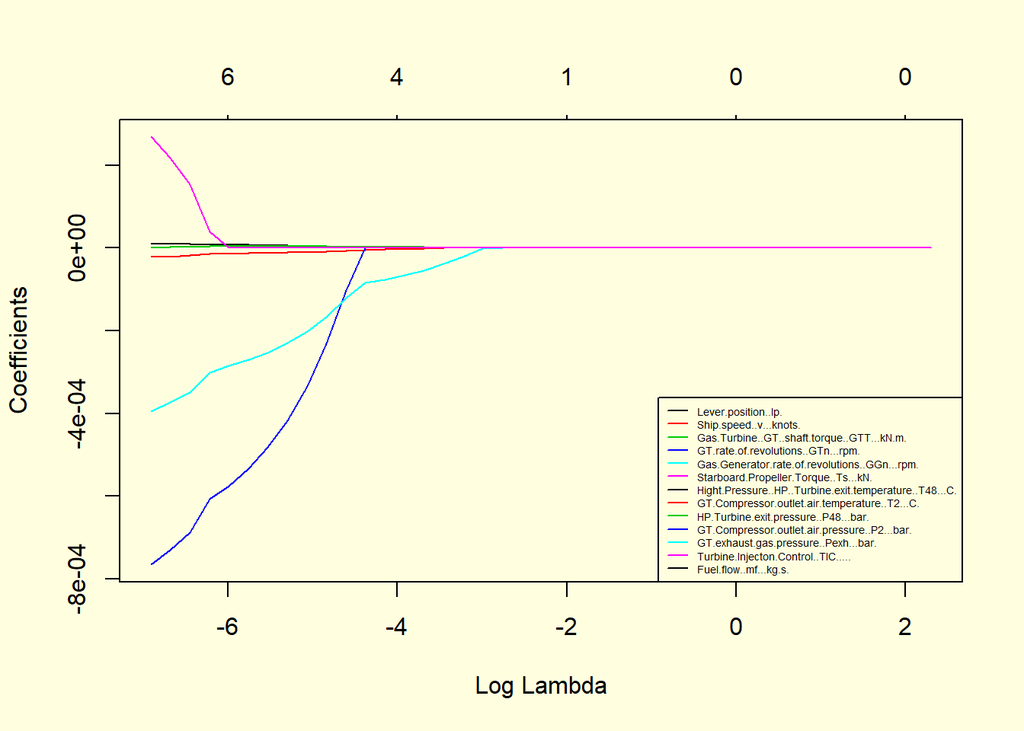

```r
plot(lasso_model, xvar = "lambda")
legend("bottomright", lwd = 1, col = 1:6, legend = colnames(x_reg), cex = .45)
```

Finding the **optimal lambda** for **losso regression** using **cross validation.**

```r
par(mfrow=c(1,1),bg="lightyellow")
set.seed(12345)

lambdas_to_try <- 10^seq(-6, 1, length.out = 50)
lasso_cv <- cv.glmnet(x_reg, y_reg, alpha = 1,lambda = lambdas_to_try ,nfolds = 100)
```

[output not shown]

[output cut: 24 more lines]

[output not shown]

[output not shown]